# Data Visualization

## Encoding with colors

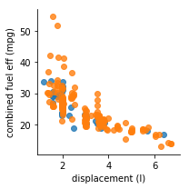

```python
# for categorical third variable, let it be trans_type ( categorical )

g = sns.FacetGrid(data = df_subset, hue = 'trans_type')
g.map(sns.regplot, 'displ', 'comb', x_jitter = 0.04, fit_reg=False)
plt.xlabel('displacement (l)')
plt.ylabel('combined fuel eff (mpg)');
```

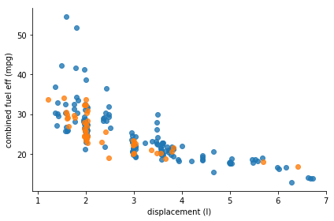

```python
# for categorical third variable, let it be trans_type ( categorical )

g = sns.FacetGrid(data = df_subset, hue = 'trans_type' , hue_order = ['Automatic','Manual'] ,size = 4,aspect = 1.5)
g.map(sns.regplot, 'displ', 'comb', x_jitter = 0.04, fit_reg=False)
plt.xlabel('displacement (l)')
plt.ylabel('combined fuel eff (mpg)');
```

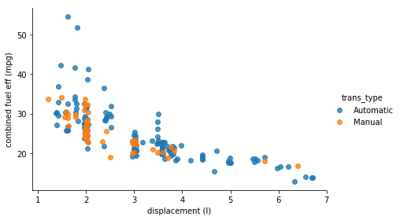

```python
# for categorical third variable, let it be trans_type ( categorical - nominal )
# Hence we use qualitative palette

g = sns.FacetGrid(data = df_subset, hue = 'trans_type' , hue_order = ['Automatic','Manual'] ,size = 4,aspect = 1.5)
g.map(sns.regplot, 'displ', 'comb', x_jitter = 0.04, fit_reg=False)
g.add_legend()
plt.xlabel('displacement (l)')
plt.ylabel('combined fuel eff (mpg)');
```

Here qualitative palette works great, what if we take VClass as third variable which is ordinal variable

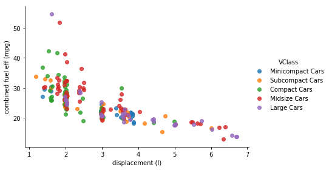

```python
# for categorical third variable VClass ( categorical - ordinal)
# Here we use sequential palette

# let's see what happens when we use qualitative palette

g = sns.FacetGrid(data = df_subset, hue = 'VClass' , size = 4,aspect = 1.5)
g.map(sns.regplot, 'displ', 'comb', x_jitter = 0.04, fit_reg=False)
g.add_legend()
plt.xlabel('displacement (l)')
plt.ylabel('combined fuel eff (mpg)');
```

we can see that it doesn't work well hence we have to use sequential palette.

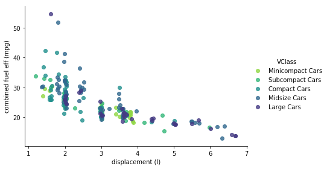

```python
# for categorical third variable VClass ( categorical - ordinal)
# Here we use sequential palette

g = sns.FacetGrid(data = df_subset, hue = 'VClass' ,
                  size = 4,aspect = 1.5 , palette = 'viridis_r')

g.map(sns.regplot, 'displ', 'comb', x_jitter = 0.04, fit_reg=False)
g.add_legend()

plt.xlabel('displacement (l)')
plt.ylabel('combined fuel eff (mpg)');
```

What if we had a numeric variable instead, like co2?

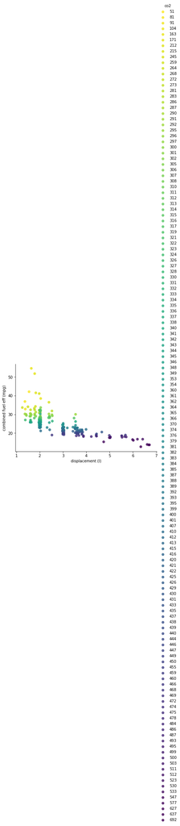

```python
g = sns.FacetGrid(data = df_subset, hue = 'co2' ,
                  size = 4,aspect = 1.5 , palette = 'viridis_r')

g.map(sns.regplot, 'displ', 'comb', x_jitter = 0.04, fit_reg=False)
g.add_legend()

plt.xlabel('displacement (l)')
plt.ylabel('combined fuel eff (mpg)');
```

we should not just replace the value in hue parameter, because the facet grid only expects to facet across categorical variables. If we do so we will get the plot as above

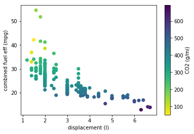

```python
# Instead we have to use the matplotlib scatter function

plt.scatter(data = df_subset , x = 'displ', y='comb', c ='co2' , cmap = 'viridis_r')
plt.colorbar(label = 'CO2 (g/mi)')

plt.xlabel('displacement (l)')
plt.ylabel('combined fuel eff (mpg)');
```

How do weights and heights compare between Fairy type Pokémon and Dragon type Pokémon? You may want to subset your dataframe before proceeding with the plotting code. **Hint**: If you remember from the univariate plots lesson, one of your axis variables may need to be transformed. If you plan on using FacetGrid, its `.set()` method will be vital for adjusting the axis scaling and tick marks. Check the [last example in the Seaborn documentation](https://seaborn.pydata.org/generated/seaborn.FacetGrid.html) for an example of how the `.set()` method is used, and the [matplotlib documentation of the Axes class](https://matplotlib.org/api/axes_api.html) for properties that you might want to set.

```python
pokemon = pd.read_csv('pokemon.csv')
pokemon.head()
```

|  | id | species | generation_id | height | weight | base_experience | type_1 | type_2 | hp | attack | defense | speed | special-attack | special-defense |
| --- | --- | --- | --- | --- | --- | --- | --- | --- | --- | --- | --- | --- | --- | --- |
| 0 | 1 | bulbasaur | 1 | 0.7 | 6.9 | 64 | grass | poison | 45 | 49 | 49 | 45 | 65 | 65 |
| 1 | 2 | ivysaur | 1 | 1.0 | 13.0 | 142 | grass | poison | 60 | 62 | 63 | 60 | 80 | 80 |
| 2 | 3 | venusaur | 1 | 2.0 | 100.0 | 236 | grass | poison | 80 | 82 | 83 | 80 | 100 | 100 |
| 3 | 4 | charmander | 1 | 0.6 | 8.5 | 62 | fire | NaN | 39 | 52 | 43 | 65 | 60 | 50 |
| 4 | 5 | charmeleon | 1 | 1.1 | 19.0 | 142 | fire | NaN | 58 | 64 | 58 | 80 | 80 | 65 |

```python
type_cols = ['type_1','type_2']
non_type_cols = pokemon.columns.difference(type_cols)
pkmn_types = pokemon.melt(id_vars = non_type_cols, value_vars = type_cols,
                          var_name = 'type_level', value_name = 'type').dropna()
pkmn_types.head()
```

|  | attack | base_experience | defense | generation_id | height | hp | id | special-attack | special-defense | species | speed | weight | type_level | type |
| --- | --- | --- | --- | --- | --- | --- | --- | --- | --- | --- | --- | --- | --- | --- |
| 0 | 49 | 64 | 49 | 1 | 0.7 | 45 | 1 | 65 | 65 | bulbasaur | 45 | 6.9 | type_1 | grass |
| 1 | 62 | 142 | 63 | 1 | 1.0 | 60 | 2 | 80 | 80 | ivysaur | 60 | 13.0 | type_1 | grass |
| 2 | 82 | 236 | 83 | 1 | 2.0 | 80 | 3 | 100 | 100 | venusaur | 80 | 100.0 | type_1 | grass |
| 3 | 52 | 62 | 43 | 1 | 0.6 | 39 | 4 | 60 | 50 | charmander | 65 | 8.5 | type_1 | fire |
| 4 | 64 | 142 | 58 | 1 | 1.1 | 58 | 5 | 80 | 65 | charmeleon | 80 | 19.0 | type_1 | fire |

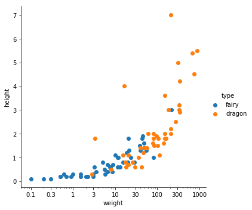

```python
pokemon_sub = pkmn_types.loc[pkmn_types['type'].isin(['fairy','dragon'])]

g = sns.FacetGrid(data = pokemon_sub, hue = 'type', size = 5)
g.map(plt.scatter, 'weight','height')
g.set(xscale = 'log') # need to set scaling before customizing ticks
x_ticks = [0.1, 0.3, 1, 3, 10, 30, 100, 300, 1000]
g.set(xticks = x_ticks, xticklabels = x_ticks)
g.add_legend()
```

## Faceting in two directions:

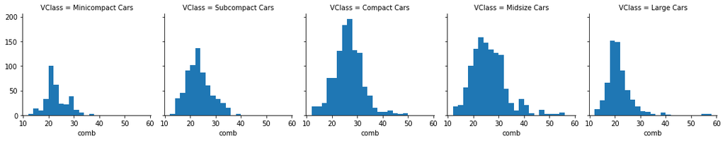

```python
# here faceting on univariate plots to get a bivariate plot.

bins = np.arange(12,58+2,2)
g = sns.FacetGrid(data = df, col = 'VClass');
g.map(plt.hist,'comb',bins = bins);
```

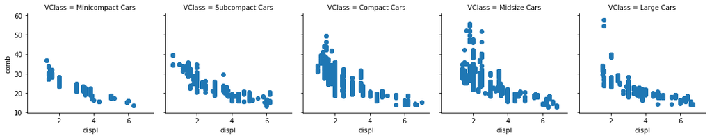

```python
# similarly we can facet on bivariate plots to get a multivariate plot.
# here we are analysing 3 variables

g = sns.FacetGrid(data = df, col = 'VClass');
g.map(plt.scatter,'displ','comb');
```

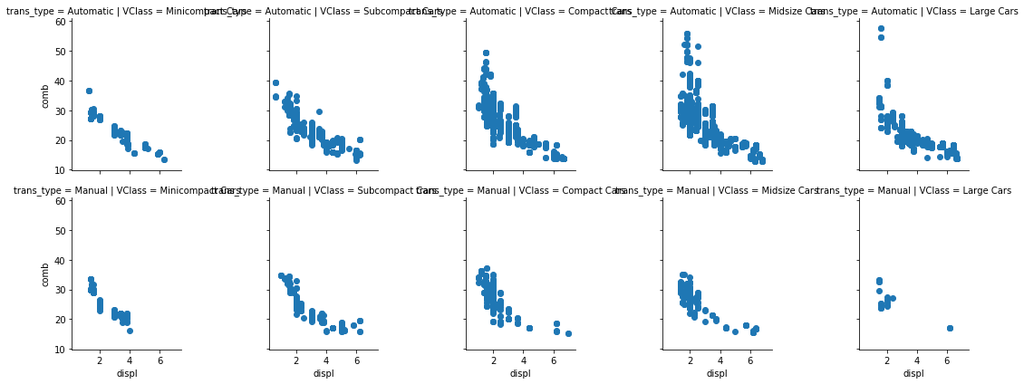

```python
# similarly we can facet on bivariate plots to get a multivariate plot.
# we can visualize four variables by adding another variable in row column

g = sns.FacetGrid(data = df, col = 'VClass', row = 'trans_type');
g.map(plt.scatter,'displ','comb');
```

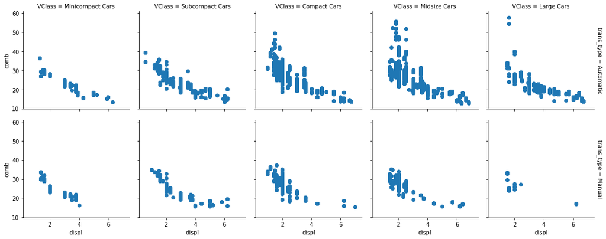

```python
# similarly we can facet on bivariate plots to get a multivariate plot.
# we can visualize four variables by adding another variable in row column

g = sns.FacetGrid(data = df, col = 'VClass', row = 'trans_type', margin_titles = True);
g.map(plt.scatter,'displ','comb');
```

## Other adaptations of bivariate plots

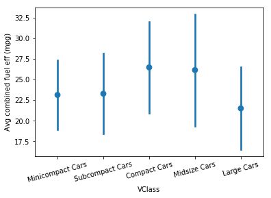

```python
# adaptation of univariate plot for a bivariate plot

sns.pointplot(data = df, x='VClass', y ='comb', ci = 'sd', linestyles = "");
plt.xticks(rotation = 15);
plt.ylabel('Avg combined fuel eff (mpg)');
```

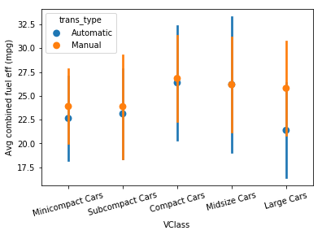

```python
# similarly we can adapt bivariate plots for multivariate

sns.pointplot(data = df, x='VClass', y ='comb',
              hue='trans_type', ci = 'sd', linestyles = "");
plt.xticks(rotation = 15);
plt.ylabel('Avg combined fuel eff (mpg)');
```

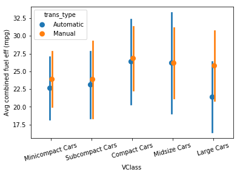

```python
# adapt a bivariate point plot to get multivariate plot

sns.pointplot(data = df, x='VClass', y ='comb',
              hue='trans_type', ci = 'sd', linestyles = "", dodge=True);
plt.xticks(rotation = 15);
plt.ylabel('Avg combined fuel eff (mpg)');
```

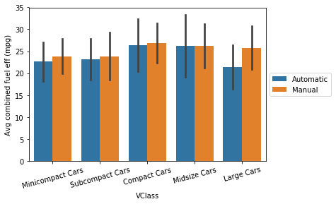

```python
# adapt a bivariate barplot to get multivariate plot

sns.barplot(data = df, x='VClass', y ='comb',
              hue='trans_type', ci = 'sd');
plt.xticks(rotation = 15);
plt.ylabel('Avg combined fuel eff (mpg)');
plt.legend(loc = 6, bbox_to_anchor = (1.0, 0.5)) # legend to right of figure
```

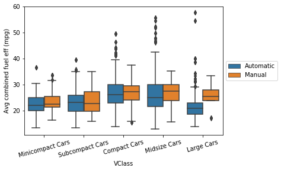

```python
# adapt a bivariate boxplot to get multivariate plot (clustered box plot)

sns.boxplot(data = df, x='VClass', y ='comb', hue='trans_type');
plt.xticks(rotation = 15);
plt.ylabel('Avg combined fuel eff (mpg)');
plt.legend(loc = 6, bbox_to_anchor = (1.0, 0.5)) # legend to right of figure
```

**We can also adapt heat maps**

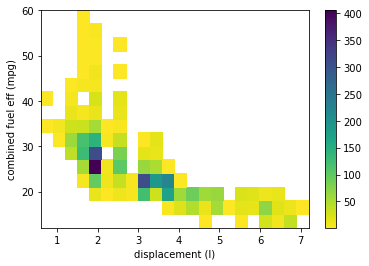

```python
# heat map for two variables

bins_x = np.arange(0.6, 7+0.3, 0.3)
bins_y = np.arange(12, 58+3, 3)

plt.hist2d(data = df, x = 'displ', y = 'comb',cmin = 0.5, cmap = 'viridis_r', bins = [bins_x,bins_y])
plt.colorbar()
plt.xlabel('displacement (l)')
plt.ylabel('combined fuel eff (mpg)');
```

We can adapt heat maps, so that instead of color being based on count, color is based on mean of third variable. Lets change this heat map of fuel efficiency against engine size (displacement), so that average co2 output is plotted instead.

```python
displ_bins = pd.cut(df['displ'],bins_x,right=False,include_lowest=False,labels=False).astype(int)
comb_bins = pd.cut(df['comb'],bins_y,right=False,include_lowest=False,labels=False).astype(int)
displ_bins
```

```
0       10
1        4
2       10
3       10
4        6
        ..
3924     4
3925     4
3926     4
3927     9
3928     9
Name: displ, Length: 3929, dtype: int64
```

```python
n_points = df.groupby([displ_bins,comb_bins]).size()
n_points
```

```
displ  comb
0      7        3
       9        3
1      6        4
       7        8
2      5       42
               ..
19     1       20
       2       15
20     0       38
       1       13
21     1        2
Length: 91, dtype: int64
```

```python
n_points = n_points.reset_index().pivot(index='displ',columns='comb').values
n_points
```

```
array([[ nan,  nan,  nan,  nan,  nan,  nan,  nan,   3.,  nan,   3.,  nan,
         nan,  nan,  nan,  nan,  nan],
       [ nan,  nan,  nan,  nan,  nan,  nan,   4.,   8.,  nan,  nan,  nan,
         nan,  nan,  nan,  nan,  nan],
       [ nan,  nan,  nan,  nan,  nan,  42.,  62.,  31.,  15.,   7.,   4.,
         nan,  nan,  nan,  nan,  nan],
       [ nan,  nan,  nan,   6.,  55., 130., 119.,  34.,   7.,  nan,   7.,
          2.,   4.,   1.,   2.,   2.],
       [ nan,  nan,  15.,  98., 405., 311., 145.,  55.,  14.,  26.,   6.,
         10.,   3.,   3.,   5.,  nan],
       [ nan,  nan,   1.,  12.,   9.,  nan,   5.,   1.,  nan,  nan,  nan,
         nan,  nan,  nan,  nan,  nan],
       [ nan,  nan,  11.,  37., 105.,  82.,  37.,   5.,  15.,  17.,  nan,
          1.,  nan,   1.,  nan,  nan],
       [ nan,  nan,   7.,   6.,  nan,  nan,  nan,  nan,  nan,  nan,  nan,
         nan,  nan,  nan,  nan,  nan],
       [ nan,  nan, 123., 311.,  64.,  17.,   2.,  nan,  nan,  nan,  nan,
         nan,  nan,  nan,  nan,  nan],
       [ nan,  nan,  32., 190.,  52.,  14.,  18.,  nan,  nan,  nan,  nan,
         nan,  nan,  nan,  nan,  nan],
       [ nan,   5., 173., 219.,   2.,  nan,  nan,  nan,  nan,  nan,  nan,
         nan,  nan,  nan,  nan,  nan],
       [ nan,  22.,  58.,   4.,  nan,  nan,  nan,  nan,  nan,  nan,  nan,
         nan,  nan,  nan,  nan,  nan],
       [ nan,  48.,  92.,  nan,  nan,  nan,  nan,  nan,  nan,  nan,  nan,
         nan,  nan,  nan,  nan,  nan],
       [  1.,  15.,  59.,  nan,  nan,  nan,  nan,  nan,  nan,  nan,  nan,
         nan,  nan,  nan,  nan,  nan],
       [ nan,  55.,  64.,  nan,  nan,  nan,  nan,  nan,  nan,  nan,  nan,
         nan,  nan,  nan,  nan,  nan],
       [ nan,   4.,  nan,  nan,  nan,  nan,  nan,  nan,  nan,  nan,  nan,
         nan,  nan,  nan,  nan,  nan],
       [  3.,  17.,  24.,  nan,  nan,  nan,  nan,  nan,  nan,  nan,  nan,
         nan,  nan,  nan,  nan,  nan],
       [ nan,  16.,  20.,  nan,  nan,  nan,  nan,  nan,  nan,  nan,  nan,
         nan,  nan,  nan,  nan,  nan],
       [ 29.,  70.,  12.,  nan,  nan,  nan,  nan,  nan,  nan,  nan,  nan,
         nan,  nan,  nan,  nan,  nan],
       [ 10.,  20.,  15.,  nan,  nan,  nan,  nan,  nan,  nan,  nan,  nan,
         nan,  nan,  nan,  nan,  nan],
       [ 38.,  13.,  nan,  nan,  nan,  nan,  nan,  nan,  nan,  nan,  nan,
         nan,  nan,  nan,  nan,  nan],
       [ nan,   2.,  nan,  nan,  nan,  nan,  nan,  nan,  nan,  nan,  nan,
         nan,  nan,  nan,  nan,  nan]])
```

```python
co2_weights = df['co2']/n_points[displ_bins,comb_bins]
co2_weights
```

```
0        2.722543
1        0.861728
2        2.479769
3        2.578035
4        3.780488
          ...
3924    15.600000
3925     8.346154
3926    35.333333
3927     2.036842
3928     2.194737
Name: co2, Length: 3929, dtype: float64
```

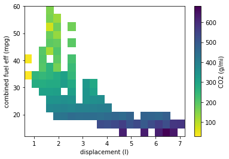

```python
bins_x = np.arange(0.6, 7+0.3, 0.3)
bins_y = np.arange(12, 58+3, 3)

# count number of points in each bin

displ_bins = pd.cut(df['displ'],bins_x,right=False,include_lowest=False,labels=False).astype(int)
comb_bins = pd.cut(df['comb'],bins_y,right=False,include_lowest=False,labels=False).astype(int)

n_points = df.groupby([displ_bins,comb_bins]).size()
n_points = n_points.reset_index()
n_points = n_points.pivot(index='displ',columns='comb').values

co2_weights = df['co2']/n_points[displ_bins,comb_bins]

# plot the data using calculated weights

plt.hist2d(data = df, x = 'displ', y = 'comb',cmin = 0.5, cmap = 'viridis_r',
           bins = [bins_x,bins_y],weights = co2_weights)
plt.colorbar(label = 'CO2 (g/mi)' )
plt.xlabel('displacement (l)')
plt.ylabel('combined fuel eff (mpg)');
```

## Plot matrices

```python
pokemon = pd.read_csv('pokemon.csv')
pokemon.head()
```

|  | id | species | generation_id | height | weight | base_experience | type_1 | type_2 | hp | attack | defense | speed | special-attack | special-defense |
| --- | --- | --- | --- | --- | --- | --- | --- | --- | --- | --- | --- | --- | --- | --- |
| 0 | 1 | bulbasaur | 1 | 0.7 | 6.9 | 64 | grass | poison | 45 | 49 | 49 | 45 | 65 | 65 |
| 1 | 2 | ivysaur | 1 | 1.0 | 13.0 | 142 | grass | poison | 60 | 62 | 63 | 60 | 80 | 80 |
| 2 | 3 | venusaur | 1 | 2.0 | 100.0 | 236 | grass | poison | 80 | 82 | 83 | 80 | 100 | 100 |
| 3 | 4 | charmander | 1 | 0.6 | 8.5 | 62 | fire | NaN | 39 | 52 | 43 | 65 | 60 | 50 |
| 4 | 5 | charmeleon | 1 | 1.1 | 19.0 | 142 | fire | NaN | 58 | 64 | 58 | 80 | 80 | 65 |

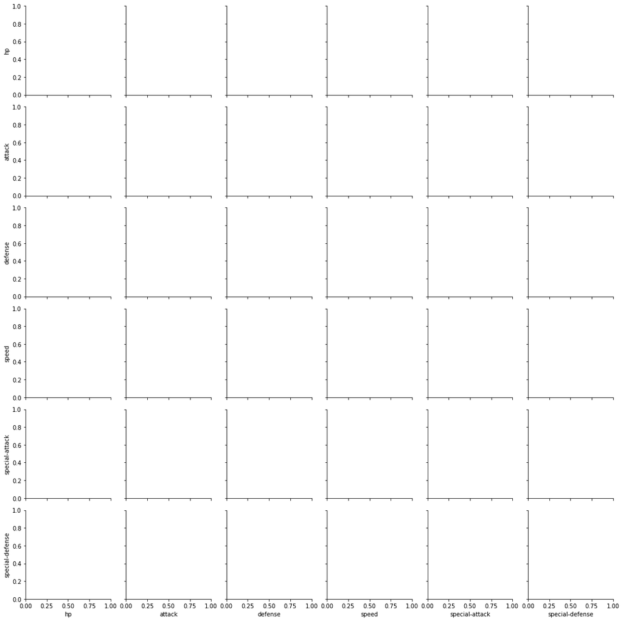

```python
stats = ['hp','attack','defense','speed','special-attack','special-defense']
g = sns.PairGrid(data = pokemon , vars = stats);
```

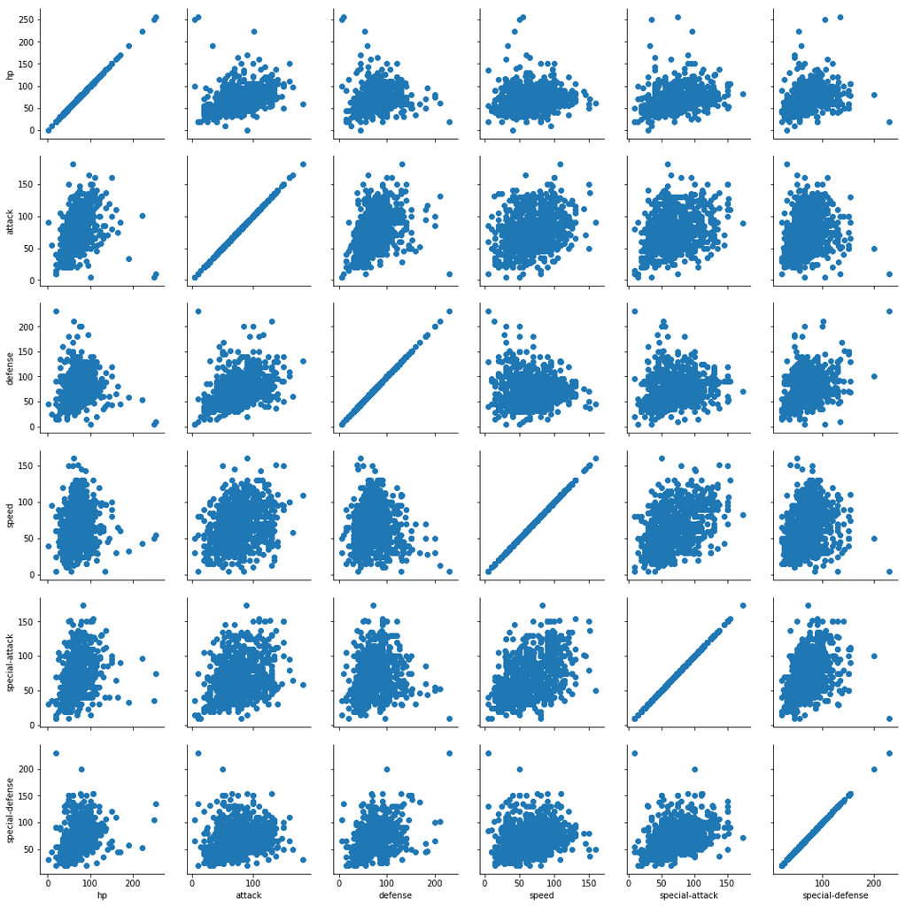

```python
# to produce pair wise scatter plots for each pair of six variables

stats = ['hp','attack','defense','speed','special-attack','special-defense']
g = sns.PairGrid(data = pokemon , vars = stats);
g = g.map(plt.scatter)
```

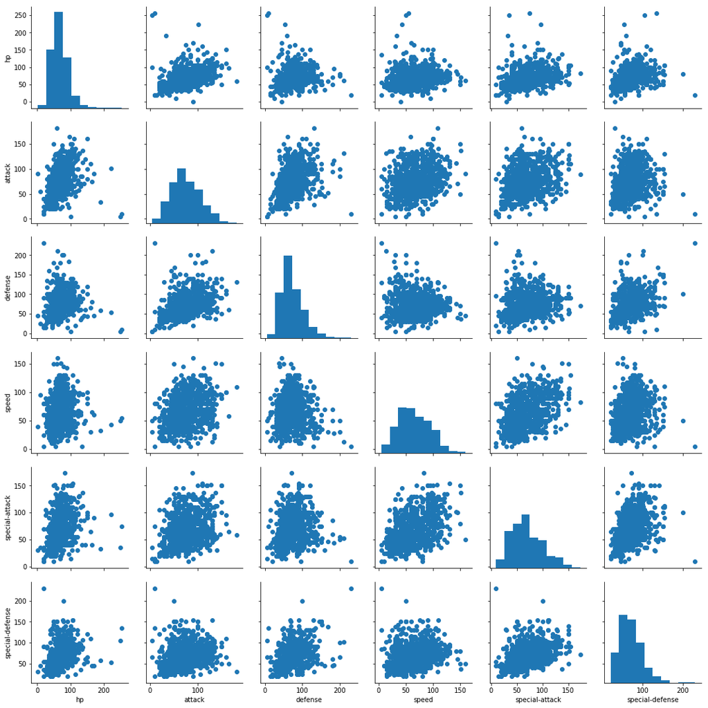

```python
# to produce pair wise scatter plots for each pair of six variables and histograms for each variable on diagonal

stats = ['hp','attack','defense','speed','special-attack','special-defense']
g = sns.PairGrid(data = pokemon , vars = stats);
g = g.map_offdiag(plt.scatter)
g.map_diag(plt.hist)
```

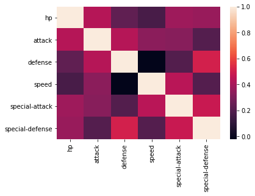

```python
sns.heatmap(pokemon[stats].corr())
```

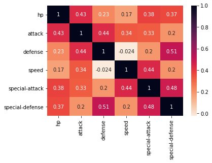

```python
sns.heatmap(pokemon[stats].corr() , annot = True , cmap = 'rocket_r')
```

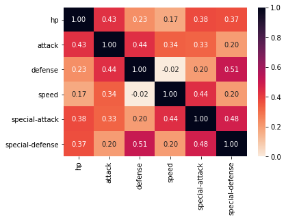

```python
sns.heatmap(pokemon[stats].corr() , annot = True , cmap = 'rocket_r',
           fmt = '.2f' , vmin =0)
```

if we want to look at the relationship between the numeric and categorical variables in the data, we need to set the different variable types on the rows and columns, then use an appropriate plot type for all matrix cells.

```
g = sb.PairGrid(data = df, x_vars = ['num_var1', 'num_var2', 'num_var3'],
                y_vars = ['cat_var1','cat_var2'])
g.map(sb.violinplot, inner = 'quartile')
```

[figure not shown]

# Feature Engineering

I want to know if a creatures offensive stats are biased towards physical or special attack, if their defesnive stats are similarly biased towards physcial or special defense.

```python
pokemon['atk_ratio'] = pokemon['attack']/pokemon['special-attack']
pokemon['def_ratio'] = pokemon['defense']/pokemon['special-defense']
```

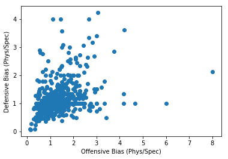

```python
plt.scatter(pokemon.atk_ratio,pokemon.def_ratio)
plt.xlabel('Offensive Bias (Phys/Spec)')
plt.ylabel('Defensive Bias (Phys/Spec)')
```

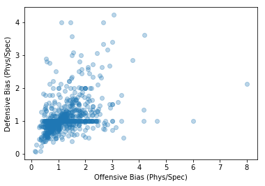

```python
plt.scatter(pokemon.atk_ratio,pokemon.def_ratio , alpha = 0.3)
plt.xlabel('Offensive Bias (Phys/Spec)')
plt.ylabel('Defensive Bias (Phys/Spec)')
```

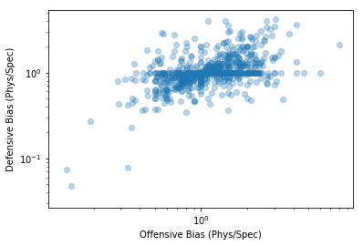

```python
plt.scatter(pokemon.atk_ratio,pokemon.def_ratio , alpha = 0.3)
plt.xlabel('Offensive Bias (Phys/Spec)')
plt.ylabel('Defensive Bias (Phys/Spec)')
plt.xscale('log')
plt.yscale('log')
```

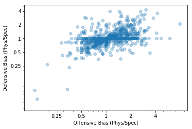

```python
plt.scatter(pokemon.atk_ratio,pokemon.def_ratio , alpha = 0.3)
plt.xlabel('Offensive Bias (Phys/Spec)')
plt.ylabel('Defensive Bias (Phys/Spec)')
plt.xscale('log')
plt.yscale('log')

tick_loc = [0.25, 0.5 , 1 , 2 , 4]
plt.xticks(tick_loc,tick_loc)
plt.yticks(tick_loc,tick_loc);
```

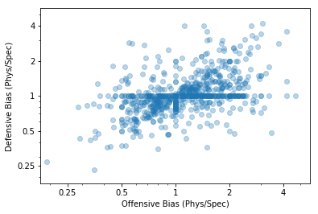

```python
plt.scatter(pokemon.atk_ratio,pokemon.def_ratio , alpha = 0.3)
plt.xlabel('Offensive Bias (Phys/Spec)')
plt.ylabel('Defensive Bias (Phys/Spec)')
plt.xscale('log')
plt.yscale('log')

tick_loc = [0.25, 0.5 , 1 , 2 , 4]
plt.xticks(tick_loc,tick_loc)
plt.yticks(tick_loc,tick_loc);

plt.xlim(2 ** -2.5, 2**2.5)
plt.ylim(2 ** -2.5, 2**2.5);
```

We can see that most points tend to fall on a diagonal line. In the upper right hand quadrant , we have pokemons that are physical biased in both offense and defense, and in the lower left hand qudrant, we have pokemons that are special biased in both offense and defense. Interestingly there appears to be a large number of pokemons on y=1 line showing no defensive bias. These pokemon have wide range of offensive biases.